# Biostat 203B Homework 5

Due Mar 22 @ 11:59PM

Author

Ziheng Zhang_606300061

## Predicting ICU duration

Using the ICU cohort `mimiciv_icu_cohort.rds` you built in Homework 4, develop at least three machine learning approaches (logistic regression with enet regularization, random forest, boosting, SVM, MLP, etc) plus a model stacking approach for predicting whether a patient’s ICU stay will be longer than 2 days. You should use the `los_long` variable as the outcome. You algorithms can use patient demographic information (gender, age at ICU `intime`, marital status, race), ICU admission information (first care unit), the last lab measurements before the ICU stay, and first vital measurements during ICU stay as features. You are welcome to use any feature engineering techniques you think are appropriate; but make sure to not use features that are not available at an ICU stay’s `intime`. For instance, `last_careunit` cannot be used in your algorithms.

1. Data preprocessing and feature engineering.

```r
library(tidyverse)
library(tidymodels)
library(gtsummary)
library(xgboost)
library(keras)
library(vip)
library(stacks)
```

```r
mimiciv_icu_cohort <-
  readRDS("../hw4/mimiciv_shiny/mimic_icu_cohort.rds") |>
  select(subject_id, hadm_id, stay_id, first_careunit, gender, race,
         marital_status, age_intime, bicarbonate, chloride, creatinine,
         glucose, potassium, sodium, hematocrit, wbc, heart_rate,
         non_invasive_blood_pressure_systolic,
         non_invasive_blood_pressure_diastolic, respiratory_rate,
         temperature_fahrenheit, los_long) |>
  mutate(race = as.character(race),
         first_careunit = as.character(first_careunit),
         los_long = as.factor(los_long))

mimiciv_icu_cohort |> tbl_summary(by = los_long, include = -c(subject_id,
                                                              hadm_id,
                                                              stay_id))
```

| **Characteristic** | **FALSE**, N = 38,050<sup>1</sup> | **TRUE**, N = 35,131<sup>1</sup> |
| --- | --- | --- |
| first_careunit |  |  |
| Cardiac Vascular Intensive Care Unit (CVICU) | 5,827 (15%) | 5,755 (16%) |
| Medical Intensive Care Unit (MICU) | 8,782 (23%) | 7,116 (20%) |
| Medical/Surgical Intensive Care Unit (MICU/SICU) | 7,147 (19%) | 5,586 (16%) |
| Other | 10,640 (28%) | 11,167 (32%) |
| Surgical Intensive Care Unit (SICU) | 5,654 (15%) | 5,507 (16%) |
| gender |  |  |
| F | 17,014 (45%) | 15,349 (44%) |
| M | 21,036 (55%) | 19,782 (56%) |
| race |  |  |
| ASIAN | 1,148 (3.0%) | 1,007 (2.9%) |
| BLACK | 4,311 (11%) | 3,649 (10%) |
| HISPANIC | 1,492 (3.9%) | 1,249 (3.6%) |
| Other | 5,160 (14%) | 5,596 (16%) |
| WHITE | 25,939 (68%) | 23,630 (67%) |
| marital_status |  |  |
| DIVORCED | 2,843 (8.0%) | 2,561 (7.9%) |
| MARRIED | 16,984 (48%) | 15,784 (49%) |
| SINGLE | 11,175 (31%) | 9,683 (30%) |
| WIDOWED | 4,699 (13%) | 4,339 (13%) |
| Unknown | 2,349 | 2,764 |
| age_intime | 65 (53, 77) | 67 (56, 78) |
| bicarbonate | 25.0 (22.0, 27.0) | 24.0 (21.0, 27.0) |
| Unknown | 4,270 | 4,780 |
| chloride | 102 (98, 105) | 102 (98, 105) |
| Unknown | 4,175 | 4,708 |
| creatinine | 1.00 (0.80, 1.40) | 1.00 (0.80, 1.60) |
| Unknown | 2,599 | 3,171 |
| glucose | 118 (98, 153) | 122 (100, 159) |
| Unknown | 4,282 | 4,817 |
| potassium | 4.20 (3.80, 4.60) | 4.20 (3.80, 4.70) |
| Unknown | 4,189 | 4,712 |
| sodium | 139.0 (136.0, 141.0) | 138.0 (135.0, 141.0) |
| Unknown | 4,174 | 4,698 |
| hematocrit | 36 (30, 40) | 35 (29, 40) |
| Unknown | 2,236 | 2,781 |
| wbc | 9.0 (6.6, 12.6) | 9.7 (7.0, 13.8) |
| Unknown | 2,272 | 2,822 |
| heart_rate | 85 (74, 99) | 88 (76, 103) |
| Unknown | 17 | 1 |
| non_invasive_blood_pressure_systolic | 122 (107, 139) | 120 (104, 138) |
| Unknown | 732 | 247 |
| non_invasive_blood_pressure_diastolic | 68 (58, 80) | 66 (55, 79) |
| Unknown | 733 | 250 |
| respiratory_rate | 18.0 (15.0, 22.0) | 19.0 (15.0, 23.0) |
| Unknown | 87 | 11 |
| temperature_fahrenheit | 98.10 (97.60, 98.60) | 98.20 (97.60, 98.80) |
| Unknown | 1,189 | 173 |

<sup>1</sup> n (%); Median (IQR)

2. Partition data into 50% training set and 50% test set. Stratify partitioning according to `los_long`. For grading purpose, sort the data by `subject_id`, `hadm_id`, and `stay_id` and use the seed `203` for the initial data split. Below is the sample code.

```r
set.seed(203)

# sort
mimiciv_icu_cohort <- mimiciv_icu_cohort |>
  arrange(subject_id, hadm_id, stay_id)

data_split <- initial_split(
  mimiciv_icu_cohort,
  # stratify by los_long
  strata = "los_long",
  prop = 0.5
  )
```

```r
mimic_train <- training(data_split) |>
  select(-subject_id, -hadm_id, -stay_id)
head(mimic_train)
```

```
# A tibble: 6 × 19
  first_careunit     gender race  marital_status age_intime bicarbonate chloride
  <chr>              <chr>  <chr> <chr>               <int>       <dbl>    <dbl>
1 Medical Intensive… F      BLACK MARRIED                76          21      109
2 Medical Intensive… F      WHITE MARRIED                83          26       85
3 Medical/Surgical … F      BLACK SINGLE                 53          24      103
4 Medical/Surgical … M      WHITE MARRIED                73          21       99
5 Other              M      WHITE SINGLE                 64          NA       NA
6 Other              M      WHITE MARRIED                33          NA       NA
# ℹ 12 more variables: creatinine <dbl>, glucose <dbl>, potassium <dbl>,
#   sodium <dbl>, hematocrit <dbl>, wbc <dbl>, heart_rate <dbl>,
#   non_invasive_blood_pressure_systolic <dbl>,
#   non_invasive_blood_pressure_diastolic <dbl>, respiratory_rate <dbl>,
#   temperature_fahrenheit <dbl>, los_long <fct>
```

```r
dim(mimic_train)
```

```
[1] 36590    19
```

```r
mimic_test <- testing(data_split) |>
  select(-subject_id, -hadm_id, -stay_id)
head(mimic_test)
```

```
# A tibble: 6 × 19
  first_careunit     gender race  marital_status age_intime bicarbonate chloride
  <chr>              <chr>  <chr> <chr>               <int>       <dbl>    <dbl>
1 Medical Intensive… F      WHITE WIDOWED                52          25       95
2 Surgical Intensiv… F      WHITE MARRIED                55          22      108
3 Surgical Intensiv… F      WHITE MARRIED                55          30      104
4 Medical/Surgical … F      WHITE MARRIED                46          NA       98
5 Cardiac Vascular … F      Other SINGLE                 57          24      102
6 Other              F      WHITE MARRIED                81          24      105
# ℹ 12 more variables: creatinine <dbl>, glucose <dbl>, potassium <dbl>,
#   sodium <dbl>, hematocrit <dbl>, wbc <dbl>, heart_rate <dbl>,
#   non_invasive_blood_pressure_systolic <dbl>,
#   non_invasive_blood_pressure_diastolic <dbl>, respiratory_rate <dbl>,
#   temperature_fahrenheit <dbl>, los_long <fct>
```

```r
dim(mimic_test)
```

```
[1] 36591    19
```

3. Train and tune the models using the training set.

**Interpretation:** There are missing values in `marital_status`, all lab measurements and all first vital measurements. Missing proportion is not high but there are some outliers for two measurements, so we will use simple median imputation for all numerical features and mode imputation for `marital_status`. **First we use Logistic Regression and the workflow is as follows:**

```r
# set recipe
logit_recipe <- recipe(los_long ~ ., data = mimic_train) |>

  # impute missing values with mean
  step_impute_median(bicarbonate, chloride, creatinine, glucose, potassium,
                       sodium, hematocrit, wbc, heart_rate,
                       non_invasive_blood_pressure_systolic,
                       non_invasive_blood_pressure_diastolic, respiratory_rate,
                       temperature_fahrenheit) |>

  # impute missing values with mode
  step_impute_mode(marital_status) |>

  # create traditional dummy variables
  step_dummy(all_nominal_predictors()) |>

  # zero-variance filter
  step_zv(all_numeric_predictors()) |>

  # center and scale numeric data
  step_normalize(all_numeric_predictors()) |>

  print()
```

```
── Recipe ──────────────────────────────────────────────────────────────────────
```

```
── Inputs
```

```
Number of variables by role
```

```
outcome:    1
predictor: 18
```

```
── Operations
```

```
• Median imputation for: bicarbonate, chloride, creatinine, glucose, ...
```

```
• Mode imputation for: marital_status
```

```
• Dummy variables from: all_nominal_predictors()
```

```
• Zero variance filter on: all_numeric_predictors()
```

```
• Centering and scaling for: all_numeric_predictors()
```

```r
# logistic regression
logit_mod <-
  logistic_reg(
    penalty = tune(),
    mixture = tune()
  ) |>
  set_engine("glmnet", standardize = FALSE)

logit_wf <- workflow() |>
  add_recipe(logit_recipe) |>
  add_model(logit_mod)
```

```r
param_grid <- grid_regular(
  penalty(range = c(-5, 1)),
  mixture(),
  levels = c(100, 5)
  )
param_grid
```

```
# A tibble: 500 × 2
     penalty mixture
       <dbl>   <dbl>
 1 0.00001         0
 2 0.0000115       0
 3 0.0000132       0
 4 0.0000152       0
 5 0.0000175       0
 6 0.0000201       0
 7 0.0000231       0
 8 0.0000266       0
 9 0.0000305       0
10 0.0000351       0
# ℹ 490 more rows
```

```r
set.seed(203)

folds <- vfold_cv(mimic_train, v = 5)

logit_fit <- logit_wf |>
  tune_grid(
    resamples = folds,
    grid = param_grid,
    metrics = metric_set(roc_auc, accuracy)
    )
```

```
# A tibble: 1,000 × 8
     penalty mixture .metric  .estimator  mean     n std_err
       <dbl>   <dbl> <chr>    <chr>      <dbl> <int>   <dbl>
 1 0.00001         0 accuracy binary     0.577     5 0.00171
 2 0.00001         0 roc_auc  binary     0.603     5 0.00252
 3 0.0000115       0 accuracy binary     0.577     5 0.00171
 4 0.0000115       0 roc_auc  binary     0.603     5 0.00252
 5 0.0000132       0 accuracy binary     0.577     5 0.00171
 6 0.0000132       0 roc_auc  binary     0.603     5 0.00252
 7 0.0000152       0 accuracy binary     0.577     5 0.00171
 8 0.0000152       0 roc_auc  binary     0.603     5 0.00252
 9 0.0000175       0 accuracy binary     0.577     5 0.00171
10 0.0000175       0 roc_auc  binary     0.603     5 0.00252
   .config
   <chr>
 1 Preprocessor1_Model001
 2 Preprocessor1_Model001
 3 Preprocessor1_Model002
 4 Preprocessor1_Model002
 5 Preprocessor1_Model003
 6 Preprocessor1_Model003
 7 Preprocessor1_Model004
 8 Preprocessor1_Model004
 9 Preprocessor1_Model005
10 Preprocessor1_Model005
# ℹ 990 more rows
```

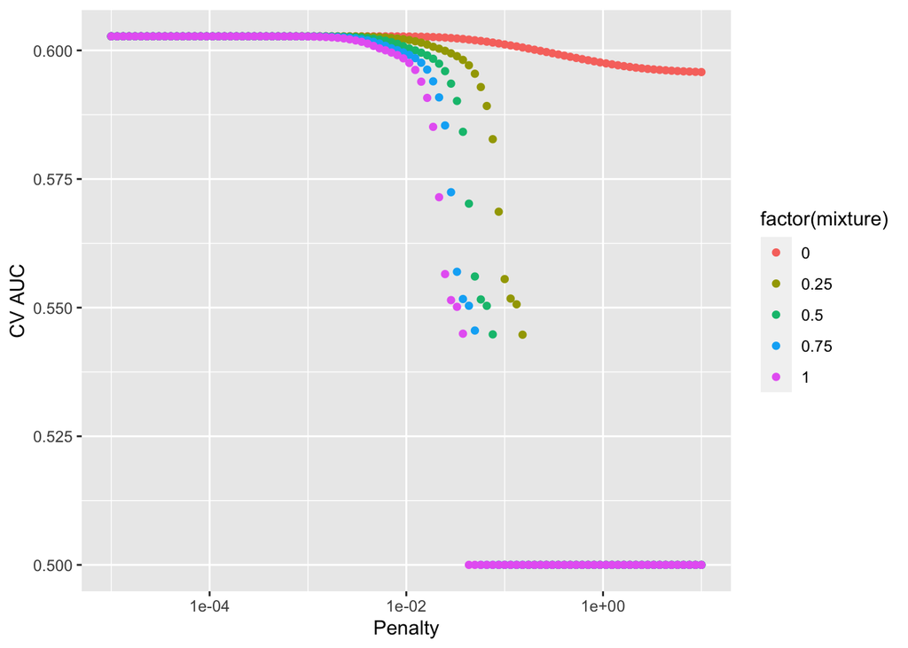

```r
logit_fit |>
  # aggregate metrics from K folds
  collect_metrics() |>
  print(width = Inf) |>
  filter(.metric == "roc_auc") |>
  ggplot(mapping = aes(x = penalty, y = mean, color = factor(mixture))) +
  geom_point() +
  labs(x = "Penalty", y = "CV AUC") +
  scale_x_log10()
```

```r
best_logit <- logit_fit |>
  select_best("roc_auc")

best_logit
```

```
# A tibble: 1 × 3
   penalty mixture .config
     <dbl>   <dbl> <chr>
1 0.000870     0.5 Preprocessor1_Model233
```

```r
final_wf_logit <- logit_wf |>
  finalize_workflow(best_logit)

final_fit_logit <- final_wf_logit |>
  last_fit(data_split)

final_fit_logit |>
  collect_metrics()
```

```
# A tibble: 2 × 4
  .metric  .estimator .estimate .config
  <chr>    <chr>          <dbl> <chr>
1 accuracy binary         0.572 Preprocessor1_Model1
2 roc_auc  binary         0.594 Preprocessor1_Model1
```

**Answer:** When `fold` = 5, the best model has `penalty` = 0.000869749 and `mixture` = 0.5. The best model has a `roc_auc` value of 0.594 and an `accuracy` of 0.572.

**Second we use XGBoost and the workflow is as follows:**

```r
# set recipe
gb_recipe <- recipe(los_long ~ ., data = mimic_train) |>

  # impute missing values with mean
  step_impute_median(bicarbonate, chloride, creatinine, glucose, potassium,
                       sodium, hematocrit, wbc, heart_rate,
                       non_invasive_blood_pressure_systolic,
                       non_invasive_blood_pressure_diastolic, respiratory_rate,
                       temperature_fahrenheit) |>

  # impute missing values with mode
  step_impute_mode(marital_status) |>

  # create traditional dummy variables
  step_dummy(all_nominal_predictors()) |>

  # zero-variance filter
  step_zv(all_numeric_predictors()) |>

  print()
```

```
── Recipe ──────────────────────────────────────────────────────────────────────
```

```
── Inputs
```

```
Number of variables by role
```

```
outcome:    1
predictor: 18
```

```
── Operations
```

```
• Median imputation for: bicarbonate, chloride, creatinine, glucose, ...
```

```
• Mode imputation for: marital_status
```

```
• Dummy variables from: all_nominal_predictors()
```

```
• Zero variance filter on: all_numeric_predictors()
```

```r
# xgboost
gb_mod <-
  boost_tree(
    mode = "classification",
    mtry = 9,
    trees = 500,
    tree_depth = tune(),
    learn_rate = tune()
  ) |>
  set_engine("xgboost")

gb_wf <- workflow() |>
  add_recipe(gb_recipe) |>
  add_model(gb_mod)
```

```r
param_grid <- grid_regular(
  tree_depth(range = c(1L, 4L)),
  learn_rate(range = c(-3, -0.5), trans = log10_trans()),
  levels = c(4, 12)
  )

param_grid
```

```
# A tibble: 48 × 2
   tree_depth learn_rate
        <int>      <dbl>
 1          1    0.001
 2          2    0.001
 3          3    0.001
 4          4    0.001
 5          1    0.00169
 6          2    0.00169
 7          3    0.00169
 8          4    0.00169
 9          1    0.00285
10          2    0.00285
# ℹ 38 more rows
```

```r
set.seed(203)

folds <- vfold_cv(mimic_train, v = 5)

gb_fit <- gb_wf |>
  tune_grid(
    resamples = folds,
    grid = param_grid,
    metrics = metric_set(roc_auc, accuracy)
    )
```

```
# A tibble: 96 × 8
   tree_depth learn_rate .metric  .estimator  mean     n std_err
        <int>      <dbl> <chr>    <chr>      <dbl> <int>   <dbl>
 1          1    0.001   accuracy binary     0.549     5 0.00385
 2          1    0.001   roc_auc  binary     0.579     5 0.00330
 3          2    0.001   accuracy binary     0.560     5 0.00311
 4          2    0.001   roc_auc  binary     0.591     5 0.00337
 5          3    0.001   accuracy binary     0.568     5 0.00368
 6          3    0.001   roc_auc  binary     0.600     5 0.00324
 7          4    0.001   accuracy binary     0.575     5 0.00279
 8          4    0.001   roc_auc  binary     0.609     5 0.00327
 9          1    0.00169 accuracy binary     0.551     5 0.00334
10          1    0.00169 roc_auc  binary     0.582     5 0.00295
   .config
   <chr>
 1 Preprocessor1_Model01
 2 Preprocessor1_Model01
 3 Preprocessor1_Model02
 4 Preprocessor1_Model02
 5 Preprocessor1_Model03
 6 Preprocessor1_Model03
 7 Preprocessor1_Model04
 8 Preprocessor1_Model04
 9 Preprocessor1_Model05
10 Preprocessor1_Model05
# ℹ 86 more rows
```

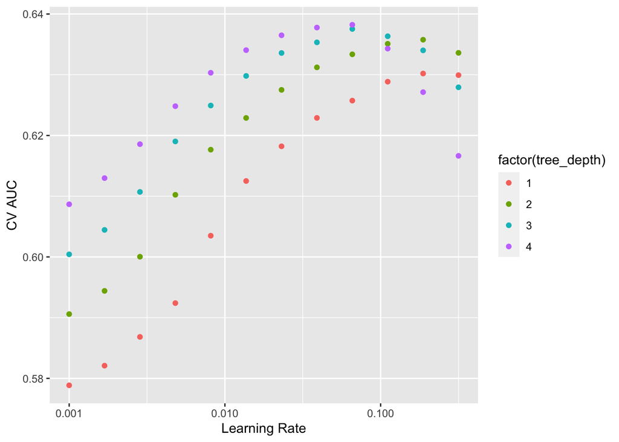

```r
gb_fit |>
  collect_metrics() |>
  print(width = Inf) |>
  filter(.metric == "roc_auc") |>
  ggplot(mapping = aes(x = learn_rate, y = mean, color = factor(tree_depth))) +
  geom_point() +
  labs(x = "Learning Rate", y = "CV AUC") +
  scale_x_log10()
```

```r
best_gb <- gb_fit |>
  select_best("roc_auc")

best_gb
```

```
# A tibble: 1 × 3
  tree_depth learn_rate .config
       <int>      <dbl> <chr>
1          4     0.0658 Preprocessor1_Model36
```

```r
final_wf_gb <- gb_wf |>
  finalize_workflow(best_gb)

final_fit_gb <- final_wf_gb |>
  last_fit(data_split)

final_fit_gb |>
  collect_metrics()
```

```
# A tibble: 2 × 4
  .metric  .estimator .estimate .config
  <chr>    <chr>          <dbl> <chr>
1 accuracy binary         0.597 Preprocessor1_Model1
2 roc_auc  binary         0.636 Preprocessor1_Model1
```

**Answer:** When `fold` = 5, the best model has `learning rate` = 0.0658 and `tree depth` = 4. The best model has a `roc_auc` value of 0.636 and an `accuracy` of 0.597.

**Third we use MLP and the workflow is as follows:**

```r
# set recipe
mlp_recipe <- recipe(los_long ~ ., data = mimic_train) |>

  # impute missing values with mean
  step_impute_median(bicarbonate, chloride, creatinine, glucose, potassium,
                       sodium, hematocrit, wbc, heart_rate,
                       non_invasive_blood_pressure_systolic,
                       non_invasive_blood_pressure_diastolic, respiratory_rate,
                       temperature_fahrenheit) |>

  # impute missing values with mode
  step_impute_mode(marital_status) |>

  # create traditional dummy variables
  step_dummy(all_nominal_predictors()) |>

  # zero-variance filter
  step_zv(all_numeric_predictors()) |>

  # center and scale numeric data
  step_normalize(all_numeric_predictors()) |>

  print()
```

```
── Recipe ──────────────────────────────────────────────────────────────────────
```

```
── Inputs
```

```
Number of variables by role
```

```
outcome:    1
predictor: 18
```

```
── Operations
```

```
• Median imputation for: bicarbonate, chloride, creatinine, glucose, ...
```

```
• Mode imputation for: marital_status
```

```
• Dummy variables from: all_nominal_predictors()
```

```
• Zero variance filter on: all_numeric_predictors()
```

```
• Centering and scaling for: all_numeric_predictors()
```

```r
mlp_mod <-
  mlp(
    mode = "classification",
    hidden_units = tune(),
    dropout = tune(),
    epochs = 30,
  ) |>
  set_engine("keras", verbose = 0)

mlp_wf <- workflow() |>
  add_recipe(mlp_recipe) |>
  add_model(mlp_mod)
```

```r
param_grid <- grid_regular(
  hidden_units(range = c(1, 20)),
  dropout(range = c(0, 0.5)),
  levels = 5
  )
param_grid
```

```
# A tibble: 25 × 2
   hidden_units dropout
          <int>   <dbl>
 1            1   0
 2            5   0
 3           10   0
 4           15   0
 5           20   0
 6            1   0.125
 7            5   0.125
 8           10   0.125
 9           15   0.125
10           20   0.125
# ℹ 15 more rows
```

```r
set.seed(203)

folds <- vfold_cv(mimic_train, v = 2)

mlp_fit <- mlp_wf |>
  tune_grid(
    resamples = folds,
    grid = param_grid,
    metrics = metric_set(roc_auc, accuracy)
    )
```

[output not shown]

[output cut: 45 more lines]

[output not shown]

```
# A tibble: 50 × 8
   hidden_units dropout .metric  .estimator  mean     n  std_err
          <int>   <dbl> <chr>    <chr>      <dbl> <int>    <dbl>
 1            1       0 accuracy binary     0.520     2 0.00107
 2            1       0 roc_auc  binary     0.5       2 0
 3            5       0 accuracy binary     0.581     2 0.000410
 4            5       0 roc_auc  binary     0.614     2 0.00127
 5           10       0 accuracy binary     0.585     2 0.000875
 6           10       0 roc_auc  binary     0.620     2 0.000292
 7           15       0 accuracy binary     0.585     2 0.000109
 8           15       0 roc_auc  binary     0.618     2 0.000858
 9           20       0 accuracy binary     0.588     2 0.00164
10           20       0 roc_auc  binary     0.619     2 0.00255
   .config
   <chr>
 1 Preprocessor1_Model01
 2 Preprocessor1_Model01
 3 Preprocessor1_Model02
 4 Preprocessor1_Model02
 5 Preprocessor1_Model03
 6 Preprocessor1_Model03
 7 Preprocessor1_Model04
 8 Preprocessor1_Model04
 9 Preprocessor1_Model05
10 Preprocessor1_Model05
# ℹ 40 more rows
```

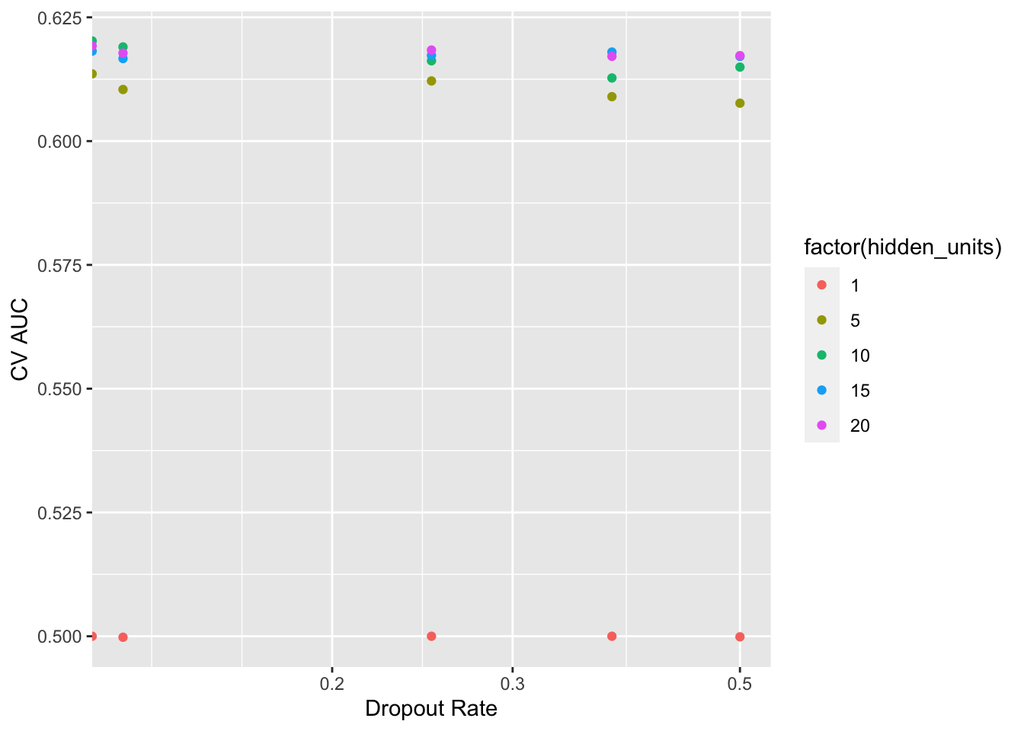

```r
mlp_fit |>
  collect_metrics() |>
  print(width = Inf) |>
  filter(.metric == "roc_auc") |>
  ggplot(mapping = aes(x = dropout, y = mean, color = factor(hidden_units))) +
  geom_point() +
  labs(x = "Dropout Rate", y = "CV AUC") +
  scale_x_log10()
```

```r
best_mlp <- mlp_fit |>
  select_best("roc_auc")

best_mlp
```

```
# A tibble: 1 × 3
  hidden_units dropout .config
         <int>   <dbl> <chr>
1           10       0 Preprocessor1_Model03
```

```r
final_wf_mlp <- mlp_wf |>
  finalize_workflow(best_mlp)

final_fit_mlp <- final_wf_mlp |>
  last_fit(data_split)
```

```
1144/1144 - 1s - 799ms/epoch - 698us/step
1144/1144 - 1s - 779ms/epoch - 681us/step
```

```r
final_fit_mlp |>
  collect_metrics()
```

```
# A tibble: 2 × 4
  .metric  .estimator .estimate .config
  <chr>    <chr>          <dbl> <chr>
1 accuracy binary         0.585 Preprocessor1_Model1
2 roc_auc  binary         0.615 Preprocessor1_Model1
```

4. Compare model classification performance on the test set. Report both the area under ROC curve and accuracy for each machine learning algorithm and the model stacking. Interpret the results. What are the most important features in predicting long ICU stays? How do the models compare in terms of performance and interpretability?

```r
set.seed(203)
folds <- vfold_cv(mimic_train, v = 2)

logit_grid <- grid_regular(
  penalty(range = c(-5, 1)),
  mixture(),
  levels = c(10, 5)
  )

gb_grid <- grid_regular(
  tree_depth(range = c(1L, 4L)),
  learn_rate(range = c(-1.6, -1), trans = log10_trans()),
  levels = c(4, 4)
  )

mlp_grid <- grid_regular(
  hidden_units(range = c(1, 20)),
  dropout(range = c(0, 0.4)),
  levels = 3
  )

logit_res <-
  tune_grid(
    object = logit_wf,
    resamples = folds,
    grid = logit_grid,
    control = control_stack_grid()
  )
```

```
ℹ The workflow being saved contains a recipe, which is 5.1 Mb in ℹ memory. If
this was not intentional, please set the control setting ℹ `save_workflow =
FALSE`.
```

```r
gb_res <-
  tune_grid(
    object = gb_wf,
    resamples = folds,
    grid = gb_grid,
    control = control_stack_grid()
  )
```

```
ℹ The workflow being saved contains a recipe, which is 5.09 Mb in ℹ memory. If
this was not intentional, please set the control setting ℹ `save_workflow =
FALSE`.
```

```r
mlp_res <-
  tune_grid(
    object = mlp_wf,
    resamples = folds,
    grid = mlp_grid,
    control = control_stack_grid()
  )
```

[output not shown]

```
ℹ The workflow being saved contains a recipe, which is 5.1 Mb in ℹ memory. If
this was not intentional, please set the control setting ℹ `save_workflow =
FALSE`.
```

```r
mimic_model_st <-
  # initialize the stack
  stacks() |>
  # add candidate members
  add_candidates(logit_res) |>
  add_candidates(gb_res) |>
  add_candidates(mlp_res) |>
  # determine how to combine their predictions
  blend_predictions(
    penalty = 10^(-4:0),
    metrics = c("roc_auc"),
    times = 3
    ) |>
  # fit the candidates with nonzero stacking coefficients
  fit_members()
```

```r
mimic_model_st
```

```
── A stacked ensemble model ─────────────────────────────────────


Out of 48 possible candidate members, the ensemble retained 11.

Penalty: 1e-04.

Mixture: 1.


The 10 highest weighted member classes are:
```

```
# A tibble: 10 × 3
   member                 type       weight
   <chr>                  <chr>       <dbl>
 1 .pred_TRUE_gb_res_1_04 boost_tree 1.49
 2 .pred_TRUE_gb_res_1_12 boost_tree 0.565
 3 .pred_TRUE_gb_res_1_16 boost_tree 0.538
 4 .pred_TRUE_mlp_res_1_2 mlp        0.311
 5 .pred_TRUE_mlp_res_1_3 mlp        0.269
 6 .pred_TRUE_mlp_res_1_9 mlp        0.181
 7 .pred_TRUE_gb_res_1_14 boost_tree 0.156
 8 .pred_TRUE_gb_res_1_11 boost_tree 0.104
 9 .pred_TRUE_mlp_res_1_5 mlp        0.0771
10 .pred_TRUE_mlp_res_1_6 mlp        0.0657
```

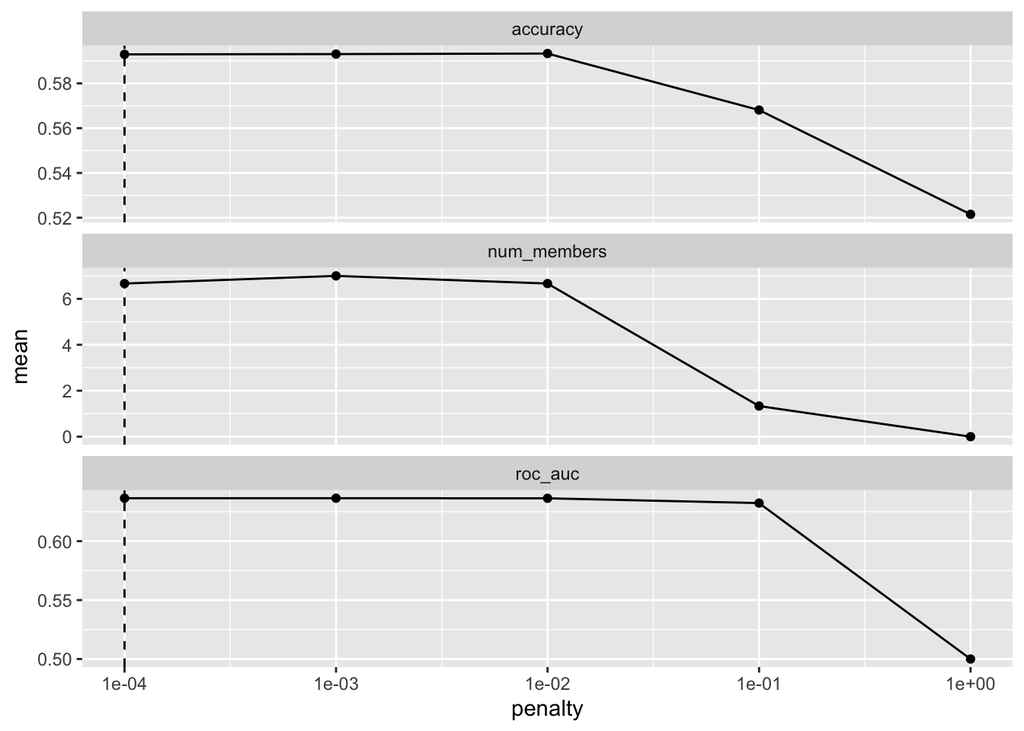

```r
autoplot(mimic_model_st)
```

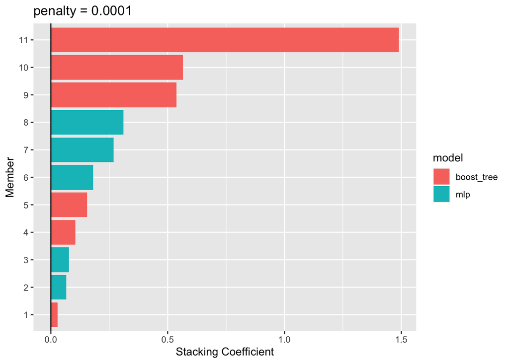

```r
autoplot(mimic_model_st, type = "weights")
```

```r
mimic_pred <- mimic_test %>%
  bind_cols(predict(mimic_model_st, ., type = "prob")) %>%
  mutate(predicted = if_else(.pred_TRUE > 0.5, "TRUE", "FALSE")) %>%
  mutate(predicted = as.factor(predicted)) %>%
  print(width = Inf)
```

```
1144/1144 - 1s - 823ms/epoch - 719us/step
1144/1144 - 1s - 879ms/epoch - 768us/step
1144/1144 - 1s - 823ms/epoch - 720us/step
1144/1144 - 1s - 861ms/epoch - 753us/step
1144/1144 - 1s - 916ms/epoch - 801us/step
# A tibble: 36,591 × 22
   first_careunit                                   gender race  marital_status
   <chr>                                            <chr>  <chr> <chr>
 1 Medical Intensive Care Unit (MICU)               F      WHITE WIDOWED
 2 Surgical Intensive Care Unit (SICU)              F      WHITE MARRIED
 3 Surgical Intensive Care Unit (SICU)              F      WHITE MARRIED
 4 Medical/Surgical Intensive Care Unit (MICU/SICU) F      WHITE MARRIED
 5 Cardiac Vascular Intensive Care Unit (CVICU)     F      Other SINGLE
 6 Other                                            F      WHITE MARRIED
 7 Medical Intensive Care Unit (MICU)               F      WHITE WIDOWED
```

[output cut: 52 more lines]

```r
final_fit_logit |>
  collect_metrics()
```

```
# A tibble: 2 × 4
  .metric  .estimator .estimate .config
  <chr>    <chr>          <dbl> <chr>
1 accuracy binary         0.572 Preprocessor1_Model1
2 roc_auc  binary         0.594 Preprocessor1_Model1
```

```r
final_fit_gb |>
  collect_metrics()
```

```
# A tibble: 2 × 4
  .metric  .estimator .estimate .config
  <chr>    <chr>          <dbl> <chr>
1 accuracy binary         0.597 Preprocessor1_Model1
2 roc_auc  binary         0.636 Preprocessor1_Model1
```

```r
final_fit_mlp |>
  collect_metrics()
```

```
# A tibble: 2 × 4
  .metric  .estimator .estimate .config
  <chr>    <chr>          <dbl> <chr>
1 accuracy binary         0.585 Preprocessor1_Model1
2 roc_auc  binary         0.615 Preprocessor1_Model1
```

```r
yardstick::accuracy(
  mimic_pred,
  truth = los_long,
  estimate = predicted
  )
```

```
# A tibble: 1 × 3
  .metric  .estimator .estimate
  <chr>    <chr>          <dbl>
1 accuracy binary         0.599
```

```r
yardstick::roc_auc(
  mimic_pred,
  truth = los_long,
  contains(".pred_FALSE")
  )
```

```
# A tibble: 1 × 3
  .metric .estimator .estimate
  <chr>   <chr>          <dbl>
1 roc_auc binary         0.637
```

[output not shown]

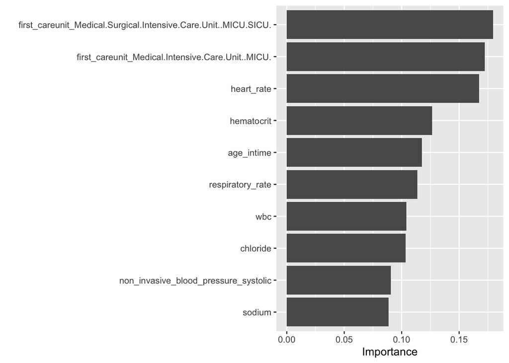

```r
# feature importance

final_fit_logit |>
  extract_fit_parsnip() |>
  vip()
```

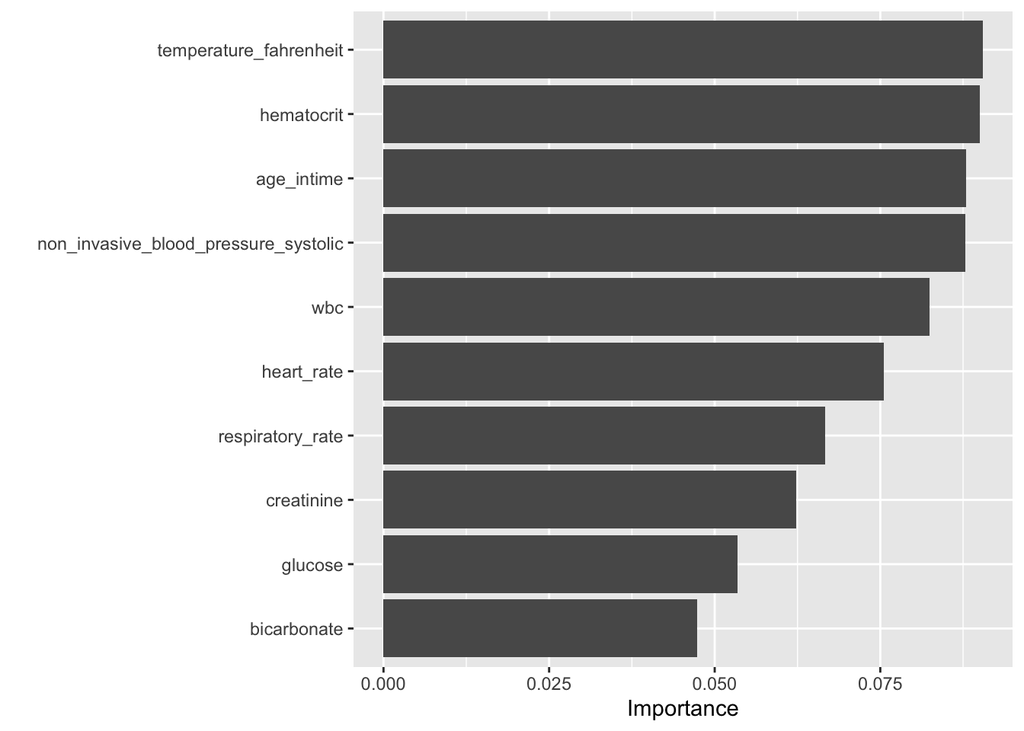

```r
final_fit_gb |>
  extract_fit_parsnip() |>
  vip()
```

**Answer:** The most important features in predicting long ICU stays are `hematocrit`, `age_intime`, `wbc`, `heart_rate`, and `respiratory_rate` in `Logistic Regression` and `XGBoost` models. `Logistic Regression` also considers two categories in `first_careunit` are important features, i.e., `Medical Intensive Care Unit (MICU)` and `Medical/Surgical Intensive Care Unit (MICU/SICU)` and they are the top two important features. It seems to be reasonable because the patients in these two units usually have more severe conditions and are more likely to have long ICU stays. It is surprising that `XGBoost` does not include any categorical variables as important features and it additionally includes `temperature_fahrenheit` as the most important feature. This may be because from `Logistic Regression` importance plot we know there is no `temperature_fahrenheit` in top 10 important features but two `first_careunit` categories are important features. Perhaps `temperature_fahrenheit` is highly correlated with the two `first_careunit` categories and then `XGBoost` shows `temperature_fahrenheit` as a replacement for the two `first_careunit` categories. For `MLP` model, it is hard to interpret the feature importance because it is a black box model. From `RStudio`, it shows model-specific variable importance scores are currently not available for this type of model. For stacked model, it is also hard to interpret the feature importance perhaps because it includes `MLP`.

There seems to be a tradeoff between performance and interpretability. The `Logistic Regression` model is the most interpretable model because it is a generalized linear model and we can interpret the coefficients of the features. However, it has the lowest `ROC_AUC` value and `accuracy`. The `XGBoost` model has the highest `ROC_AUC` value and `accuracy` but it is not as interpretable as the `Logistic Regression` model. The `MLP` model is the least interpretable model because it is a black box model and it has complex non-linear structures. So it is extremely hard or practically impossible to interpret. The stacked model has the highest `ROC_AUC` value and `accuracy` and it is not as interpretable as the `Logistic Regression` model but it is more interpretable than the `MLP` model. This increased interpretability may be due to its ensemble nature, which combines the `XGBoost` and `MLP` models in a weighted manner. The combination of the `XGBoost` and `MLP` models also contributes to the highest `ROC_AUC` value and `accuracy` of the stacked model among the four models.